# CDC Daily by State

davegoblue

5/27/2021

## Background

This file is designed to use CDC data to assess coronavirus disease burden by state, including creating and analyzing state-level cluters.

Through March 7, 2021, [The COVID Tracking Project](https://covidtracking.com/) collected and integrated data on tests, cases, hospitalizations, deaths, and the like by state and date. The latest code for using this data is available in Coronavirus_Statistics_CTP_v004.Rmd.

The COVID Tracking Project suggest that [US federal data sources](https://covidtracking.com/analysis-updates/federal-covid-data-101-how-to-find-data) are now sufficiently robust to be used for analyses that previously relied on COVID Tracking Project. This code is an attempt to update modules in Coronavirus_Statistics_CTP_v004.Rmd to leverage US federal data.

The code in this module builds on code available in _v001, and splits many functions in to two main .R files that can be sourced:

- Generic_Added_Utility_Functions_202105_v001.R - generic functions that can be used in other areas
- Coronavirus_CDC_Daily_Functions_v001.R - functions specific to coronavirus daily data

Broadly, the CDC data analyzed by this module includes:

- CDC case and death data by state and date are available for download on the [CDC website](https://data.cdc.gov/api/views/9mfq-cb36/rows.csv?accessType=DOWNLOAD)
- CDC hospital data are available for download on the [healthdata.gov website](https://beta.healthdata.gov/api/views/g62h-syeh/rows.csv?accessType=DOWNLOAD)

## Functions and Mapping Files

The tidyverse package is loaded and functions are sourced:

```r
# The tidyverse functions are routinely used without package::function format
library(tidyverse)
# Functions are available in source file
source("./Generic_Added_Utility_Functions_202105_v001.R")
source("./Coronavirus_CDC_Daily_Functions_v001.R")
```

A series of mapping files are also available to allow for parameterized processing. Mappings include:

- urlMapper - mapping file for urlType and url location to download data
- renMapper - mapping file for renaming of variables in the raw data file
- selfListMapper - mapping file for transformations by variable type
- fullListMapper - mapping file for transformations across variable types
- lstComboMapper - mapping file for elements to be combined by data type (most common is to combine NYC and NYS data to NY if the file provides them separately)
- uqMapper - mapping file for fields that should combine to be unique keys for processed files
- lstFilterMapper - mapping file for filtering to subset (most common is to keep 50 states and DC)
- vecSelectMapper - mapping file for variables to keep
- checkControlGroupMapper - mapping file for group_by() of control total checks
- checkControlAggMapper - mapping file for numeric variables for control total checks
- checkSimilarityMapper - mapping file for similarity checks to perform
- plotSimilarityMaooer - mapping file for fields where differences in universe should be plotted
- keyAggMapper - mapping file for the aggregate-level control total checks to perform
- perCapMapper - named vector that drives conversion from original field name to per capita field name

These default parameters are maintained in a separate .R file and can be sourced:

```r
source("./Coronavirus_CDC_Daily_Default_Mappings_v002.R")
```

Additionally, a mapping file could be maintained to give default plotting labels to variables. This is currently not used by any of the sourced functions:

```r
# Create a variable mapping file - this is currently redundant
varMapper <- c()
```

## Example for Comparison to Previous

Code from the previous model is run, with results compared to previous results:

```
##
## No file has been downloaded, will use existing file: ./RInputFiles/Coronavirus/CDC_dc_downloaded_210502.csv
```

```
##
## *** File has been checked for uniqueness by: state date
```

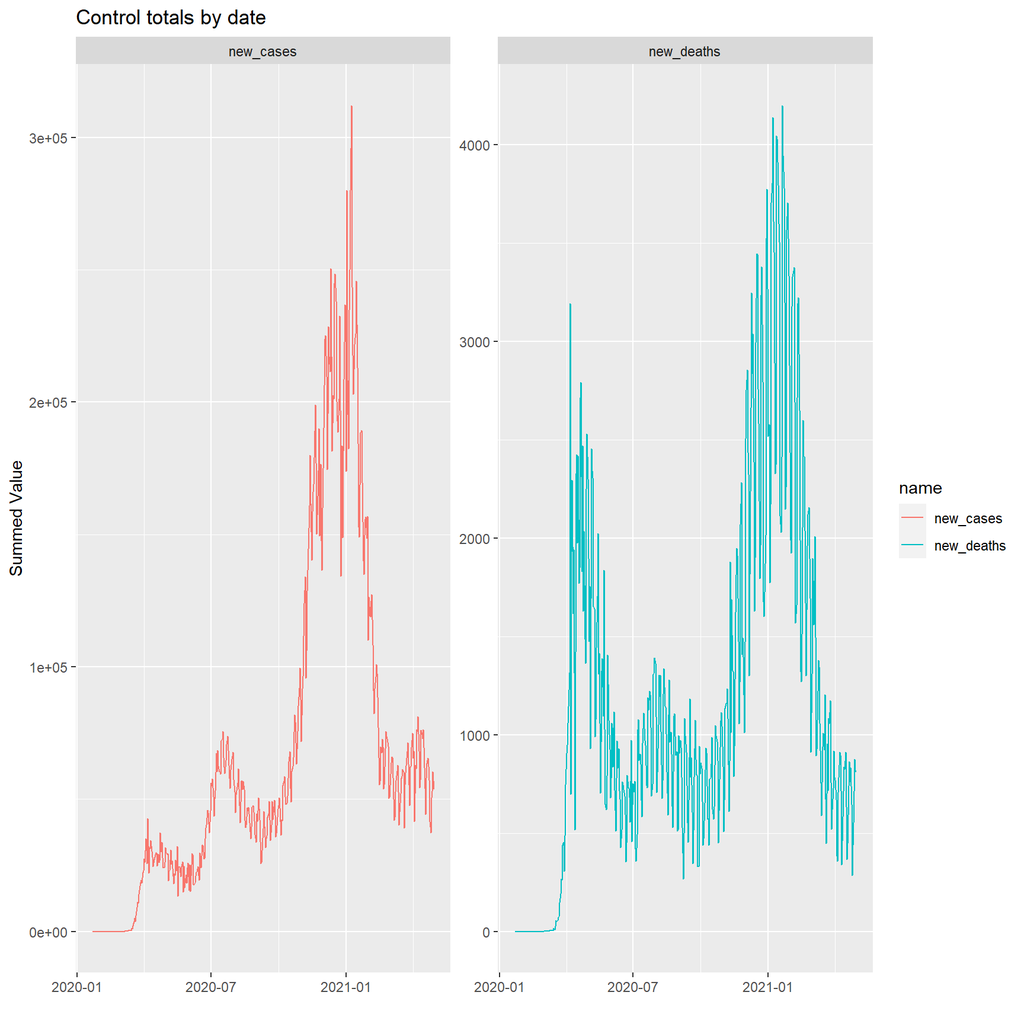

```
##
##
## Checking for similarity of: column names
## In reference but not in current: naconf
## In current but not in reference:
##
## Checking for similarity of: date
## In reference but not in current: 0
## In current but not in reference: 18
## Detailed differences available in: ./RInputFiles/Coronavirus/Coronavirus_CDC_Daily_v002.log
##
## Checking for similarity of: state
## In reference but not in current:
## In current but not in reference:
```

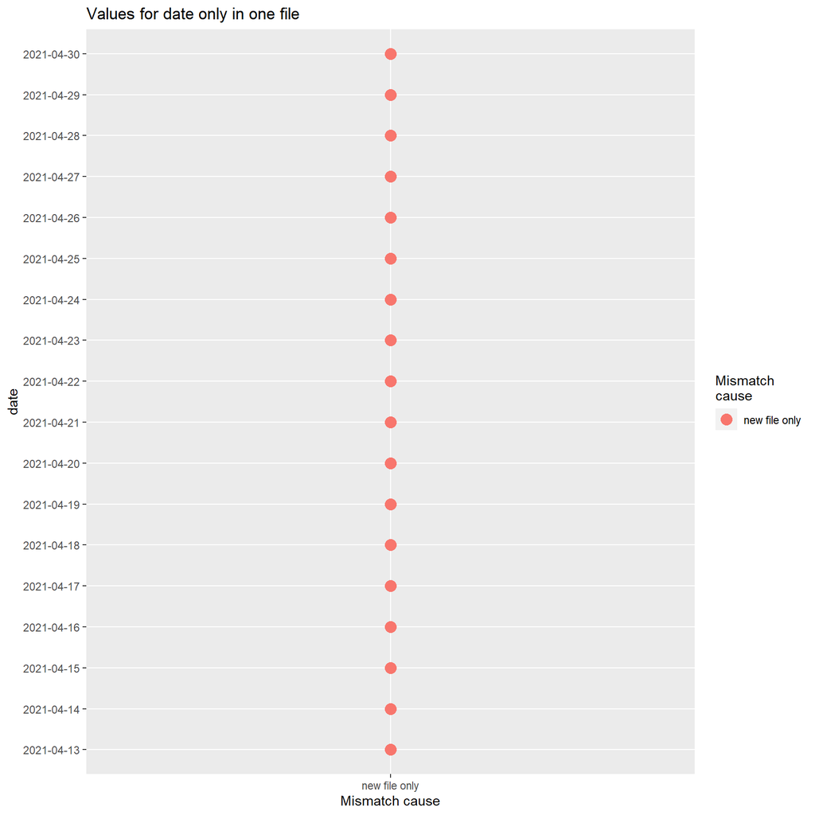

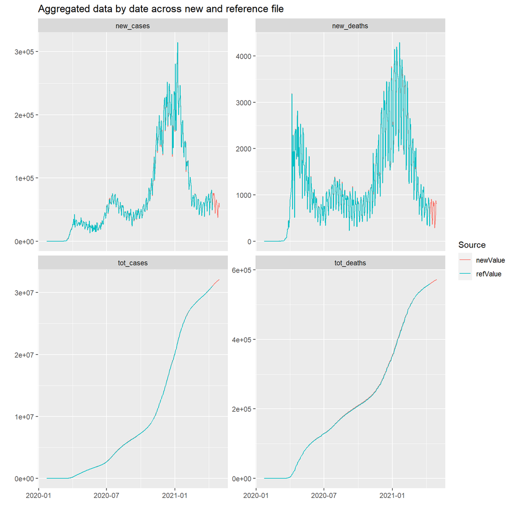

```
##
##
## ***Differences of at least 5 and at least 5%
##
## 97 records
## Detailed output available in log: ./RInputFiles/Coronavirus/Coronavirus_CDC_Daily_v002.log
```

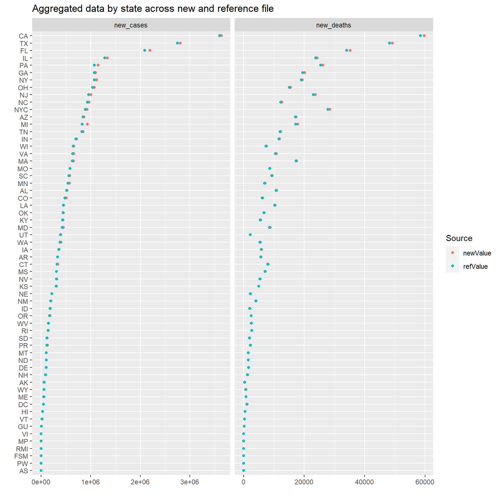

```
##
##
## ***Differences of at least 0 and at least 0.1%
##
## 14 records
## Detailed output available in log: ./RInputFiles/Coronavirus/Coronavirus_CDC_Daily_v002.log
##
##
## No file has been downloaded, will use existing file: ./RInputFiles/Coronavirus/CDC_h_downloaded_210509.csv
```

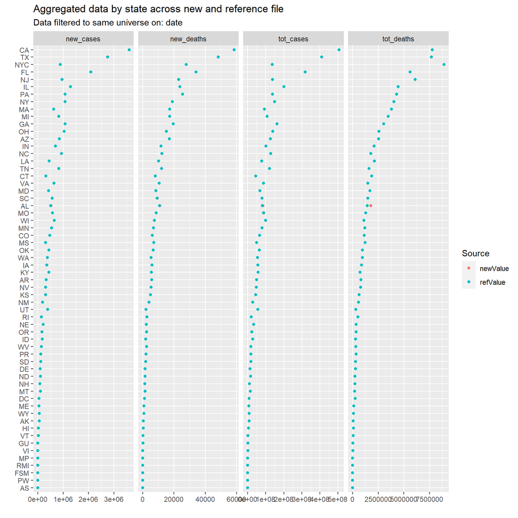

```
##
## *** File has been checked for uniqueness by: state date
```

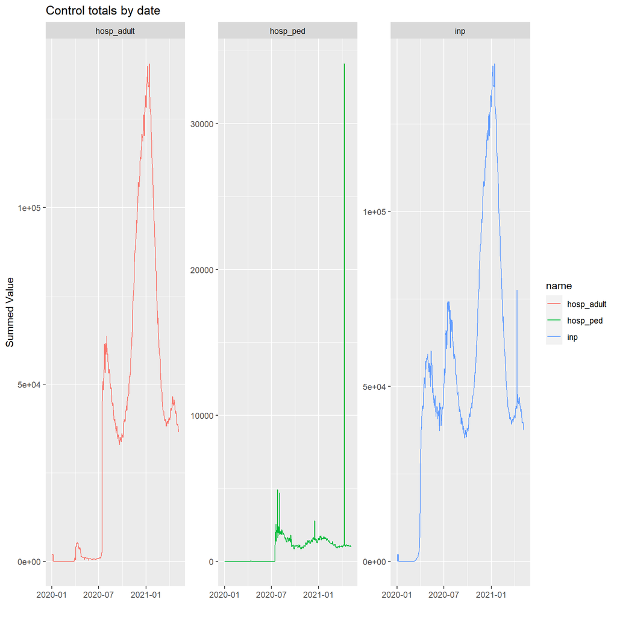

```
##
##
## Checking for similarity of: column names
## In reference but not in current:
## In current but not in reference: previous_day_admission_adult_covid_confirmed_18-19 previous_day_admission_adult_covid_confirmed_18-19_coverage previous_day_admission_adult_covid_confirmed_20-29 previous_day_admission_adult_covid_confirmed_20-29_coverage previous_day_admission_adult_covid_confirm…
##
## Checking for similarity of: date
## In reference but not in current: 0
## In current but not in reference: 15
## Detailed differences available in: ./RInputFiles/Coronavirus/Coronavirus_CDC_Daily_v002.log
##
## Checking for similarity of: state
## In reference but not in current:
## In current but not in reference:
```

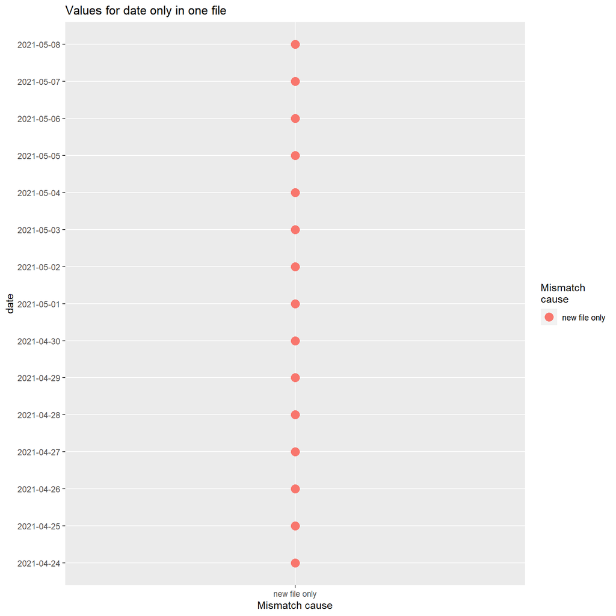

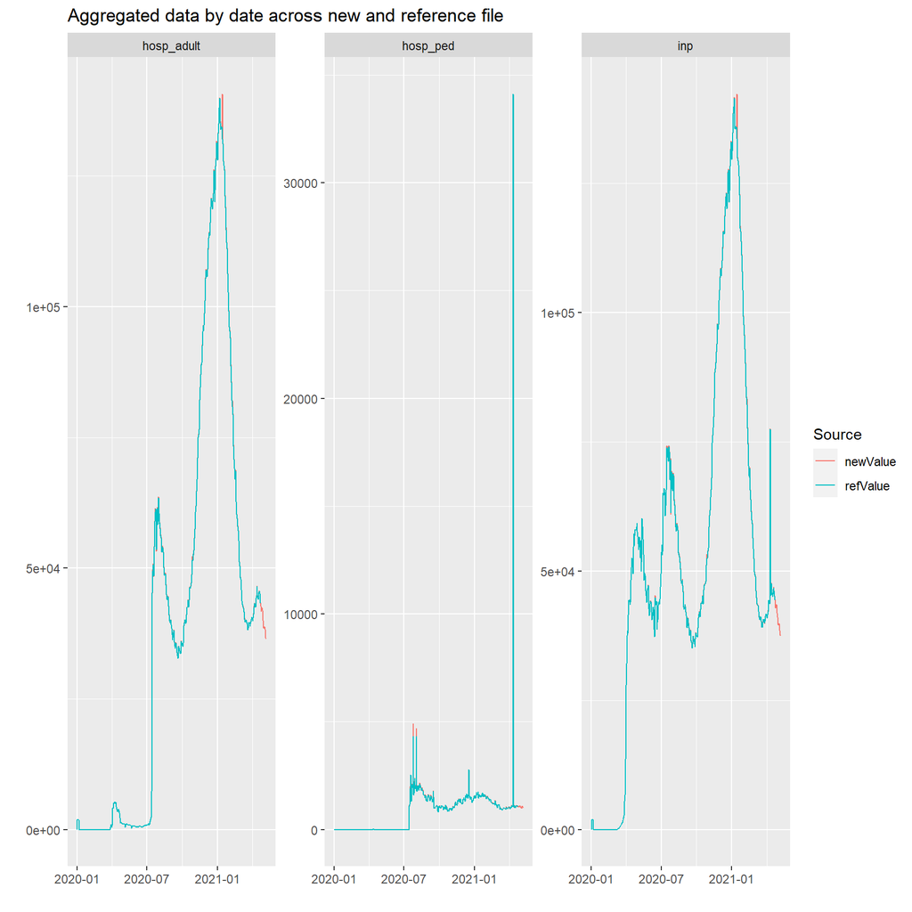

```
##
##
## ***Differences of at least 5 and at least 5%
##
## 6 records
## Detailed output available in log: ./RInputFiles/Coronavirus/Coronavirus_CDC_Daily_v002.log
```

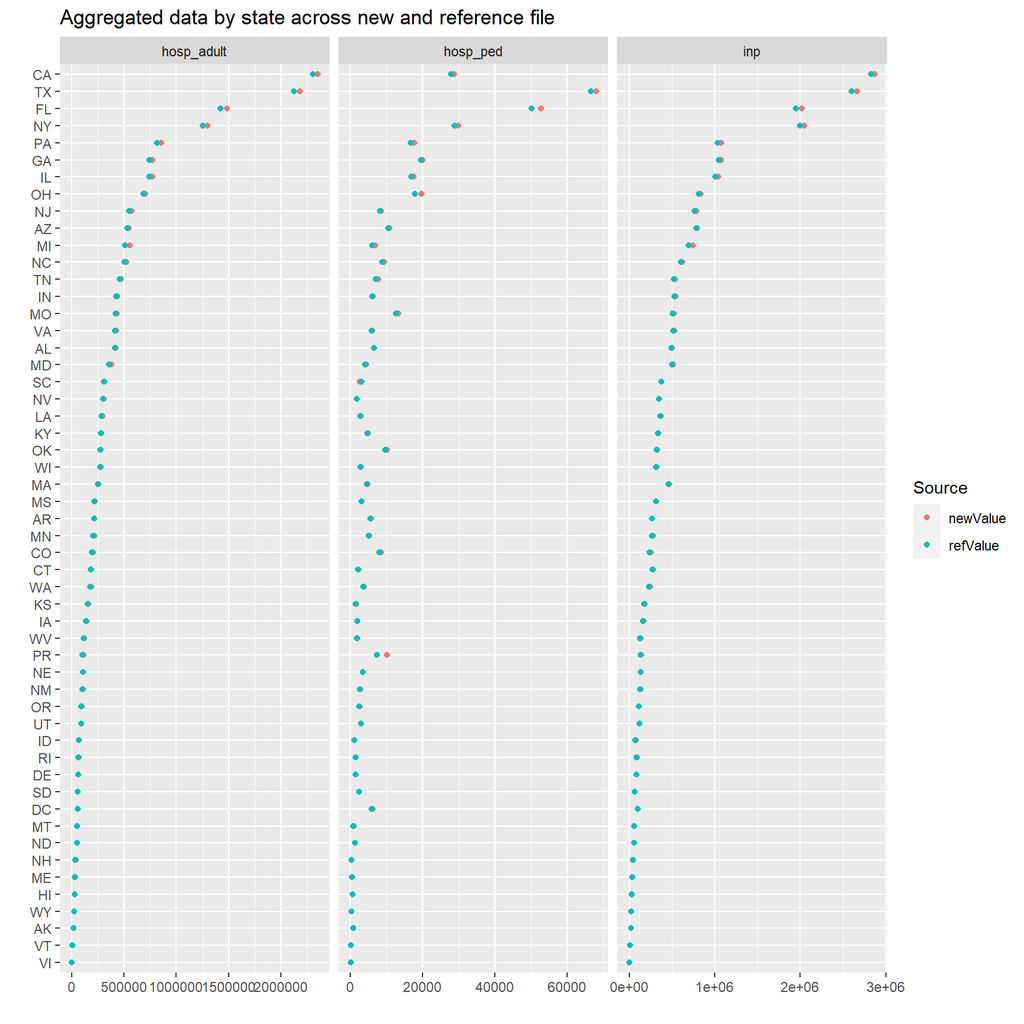

```
##
##
## ***Differences of at least 0 and at least 0.1%
##
## 63 records
## Detailed output available in log: ./RInputFiles/Coronavirus/Coronavirus_CDC_Daily_v002.log
##
##
## Column sums before and after applying filtering rules:
## # A tibble: 3 x 6
##   isType tot_cases tot_deaths new_cases   new_deaths         n
##   <chr>      <dbl>      <dbl>     <dbl>        <dbl>     <dbl>
## 1 before   5.08e+9    1.07e+8   3.21e+7 558830       27435
## 2 after    5.06e+9    1.06e+8   3.19e+7 556355       23715
## 3 pctchg   4.40e-3    3.81e-3   4.47e-3      0.00443     0.136
##
##
## Column sums before and after applying filtering rules:
## # A tibble: 3 x 5
##   isType     inp hosp_adult    hosp_ped          n
##   <chr>    <dbl>      <dbl>       <dbl>      <dbl>
## 1 before 2.57e+7    1.99e+7 436353      23230
## 2 after  2.56e+7    1.98e+7 426239      22395
## 3 pctchg 5.60e-3    5.66e-3      0.0232     0.0359
```

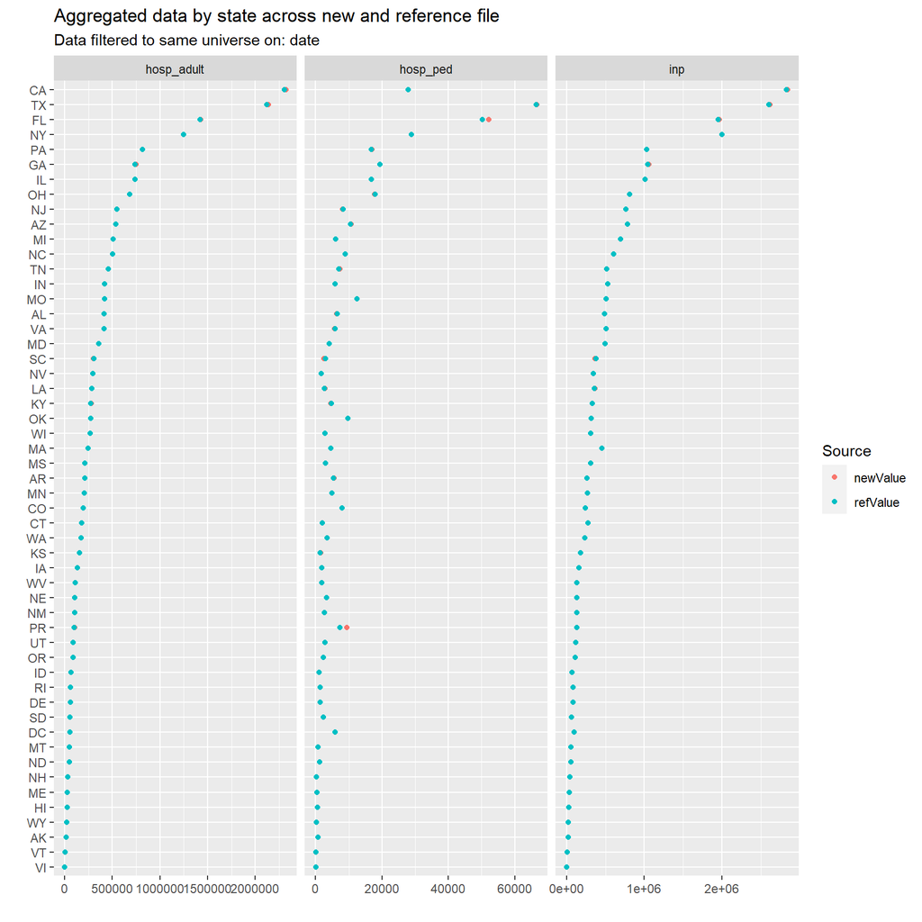

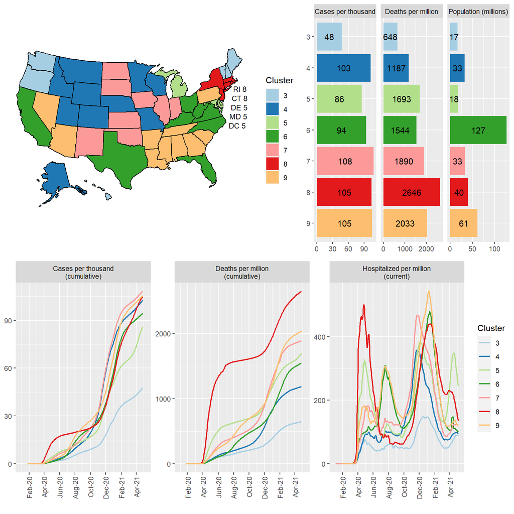

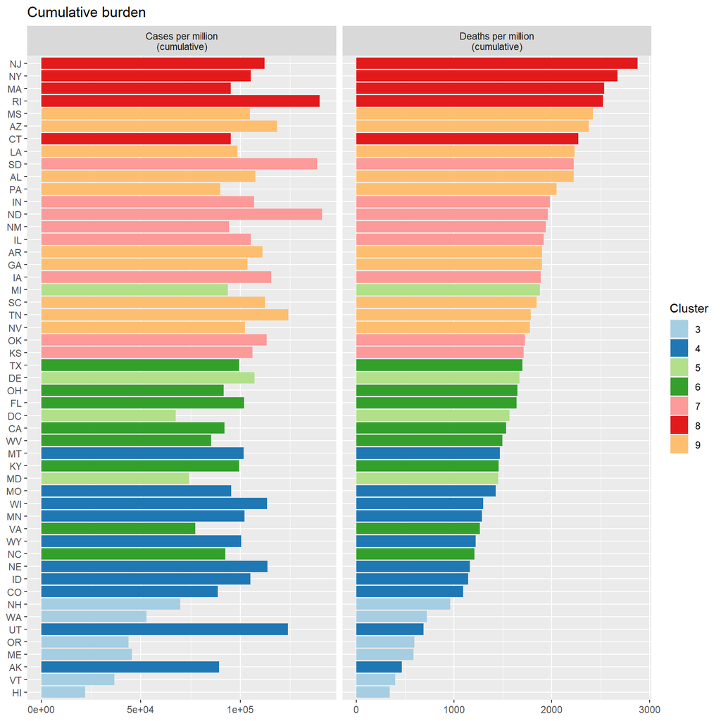

[2 more figures not shown]

```r
readList <- list("cdcDaily"="./RInputFiles/Coronavirus/CDC_dc_downloaded_210502.csv",
                 "cdcHosp"="./RInputFiles/Coronavirus/CDC_h_downloaded_210509.csv"
                 )

cdc_daily_compare <- readRunCDCDaily(thruLabel="May 2, 2021",
                                     readFrom=readList,
                                     compareFile=list("cdcDaily"=colRenamer(readFromRDS("dfRaw_dc_210414"),
                                                                            c('new_case'='new_cases',
                                                                              'tot_death'='tot_deaths',
                                                                              'new_death'='new_deaths'
                                                                              )
                                                                            ),
                                                      "cdcHosp"=readFromRDS("dfHosp_old")
                                                      ),
                                     writeLog="./RInputFiles/Coronavirus/Coronavirus_CDC_Daily_v002.log",
                                     ovrwriteLog=TRUE,
                                     dfPerCapita=NULL,
                                     useClusters=readFromRDS("cdc_daily_test_v2")$useClusters,
                                     skipAssessmentPlots=FALSE,
                                     brewPalette="Paired"
                                     )
```

```r
identical(cdc_daily_compare[c("stateData", "dfRaw", "dfProcess", "dfPerCapita", "useClusters")],
          readFromRDS("cdc_daily_test_v3")[c("stateData", "dfRaw", "dfProcess", "dfPerCapita", "useClusters")]
          )
```

```
## [1] TRUE
```

```r
identical(cdc_daily_compare$plotDataList[c("dfFull", "dfAgg", "plotClusters")],
          readFromRDS("cdc_daily_test_v3")$plotDataList[c("dfFull", "dfAgg", "plotClusters")]
          )
```

```
## [1] TRUE
```

The core data elements are identical, and the plots appear to convey the same information. Next steps are to download the latest data and process with existing clusters.

Updated data are downloaded and processed, using existing segments. The downloadTo argument is edited using lapply to avoid downloading data if it has previously been downloaded:

```
##
## *** File has been checked for uniqueness by: state date
```

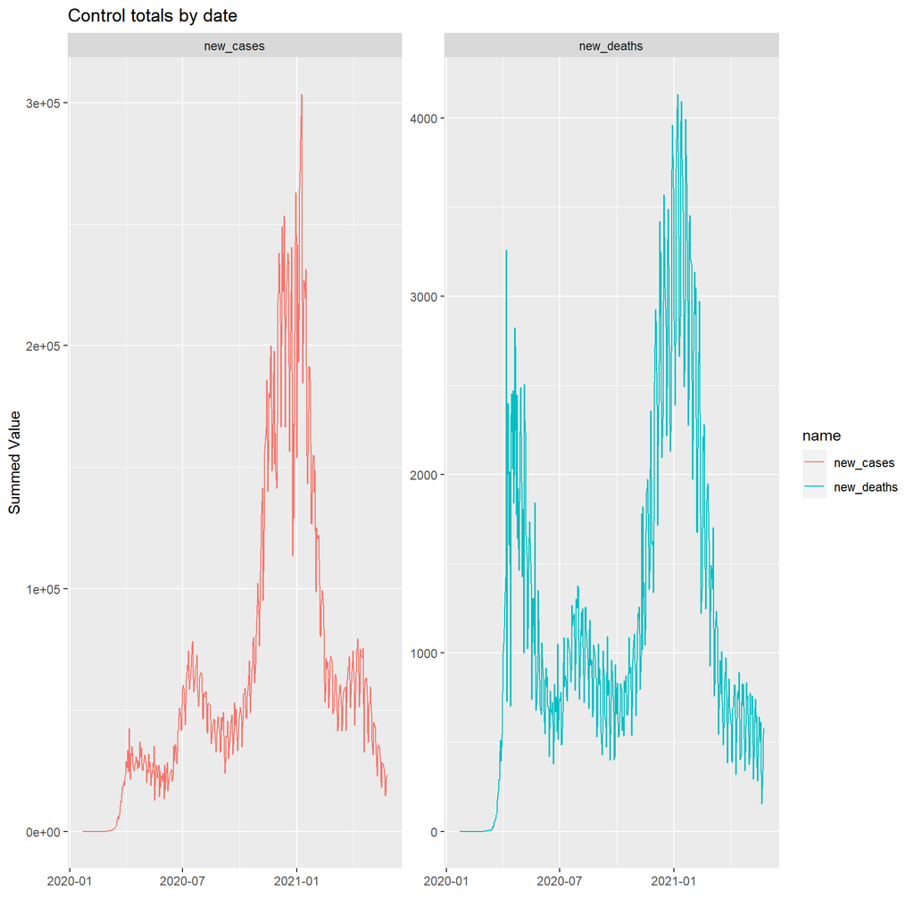

```
##
##
## Checking for similarity of: column names
## In reference but not in current:
## In current but not in reference:
##
## Checking for similarity of: date
## In reference but not in current: 0
## In current but not in reference: 26
## Detailed differences available in: ./RInputFiles/Coronavirus/Coronavirus_CDC_Daily_210528.log
##
## Checking for similarity of: state
## In reference but not in current:
## In current but not in reference:
```

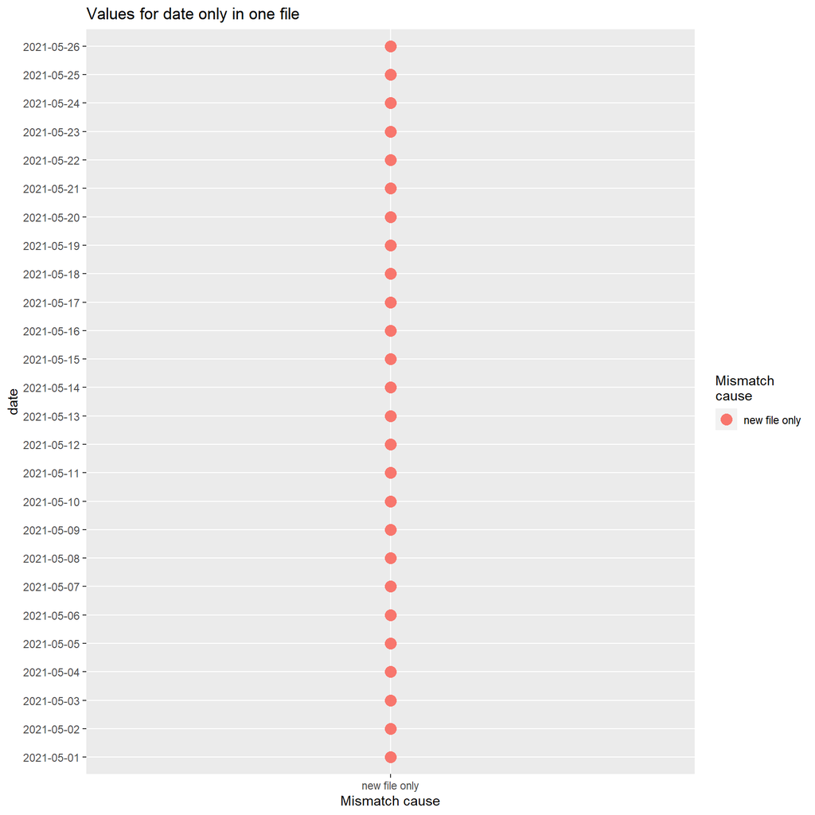

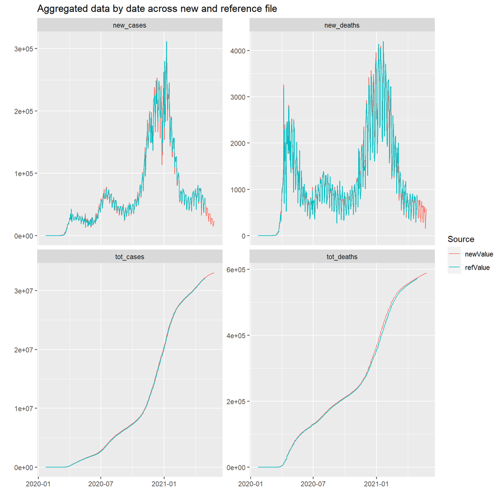

```
##
##
## ***Differences of at least 5 and at least 5%
##
## 593 records
## Detailed output available in log: ./RInputFiles/Coronavirus/Coronavirus_CDC_Daily_210528.log
```

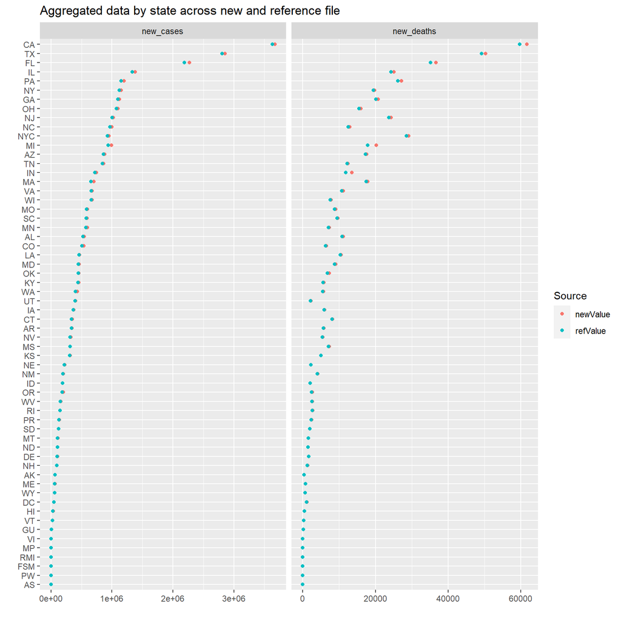

```
##
##
## ***Differences of at least 0 and at least 0.1%
##
## 39 records
## Detailed output available in log: ./RInputFiles/Coronavirus/Coronavirus_CDC_Daily_210528.log
```

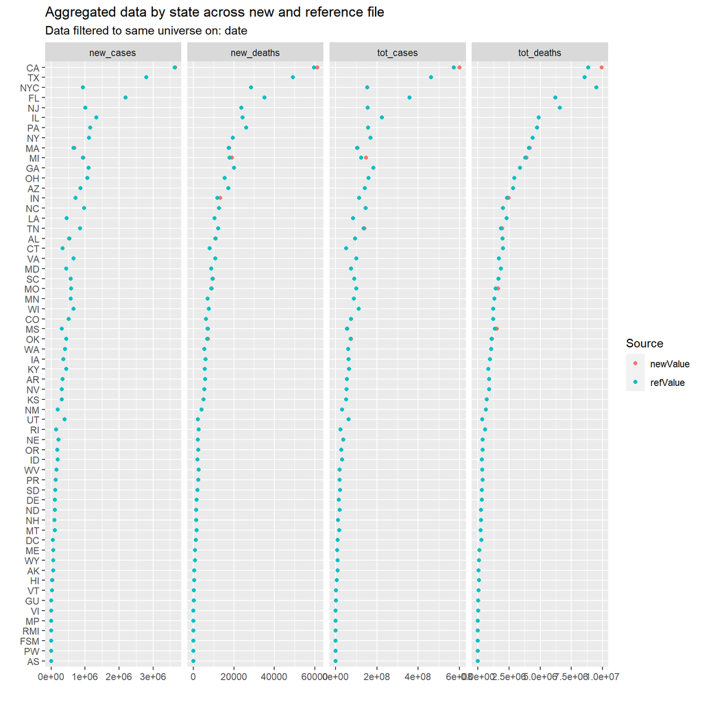

```
##
## *** File has been checked for uniqueness by: state date
```

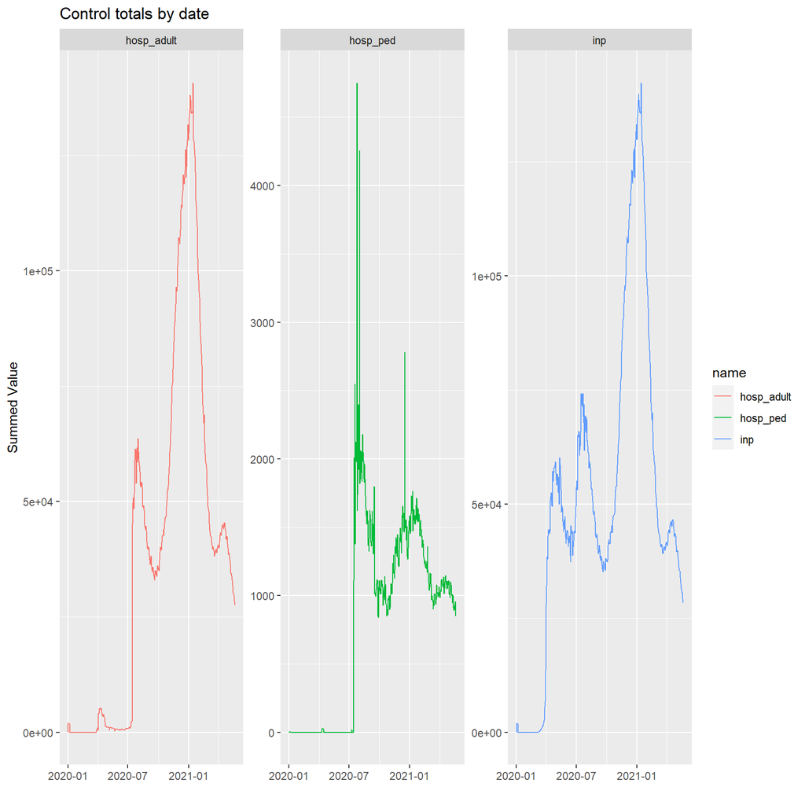

```
##
##
## Checking for similarity of: column names
## In reference but not in current:
## In current but not in reference:
##
## Checking for similarity of: date
## In reference but not in current: 0
## In current but not in reference: 14
## Detailed differences available in: ./RInputFiles/Coronavirus/Coronavirus_CDC_Daily_210528.log
##
## Checking for similarity of: state
## In reference but not in current:
## In current but not in reference:
```

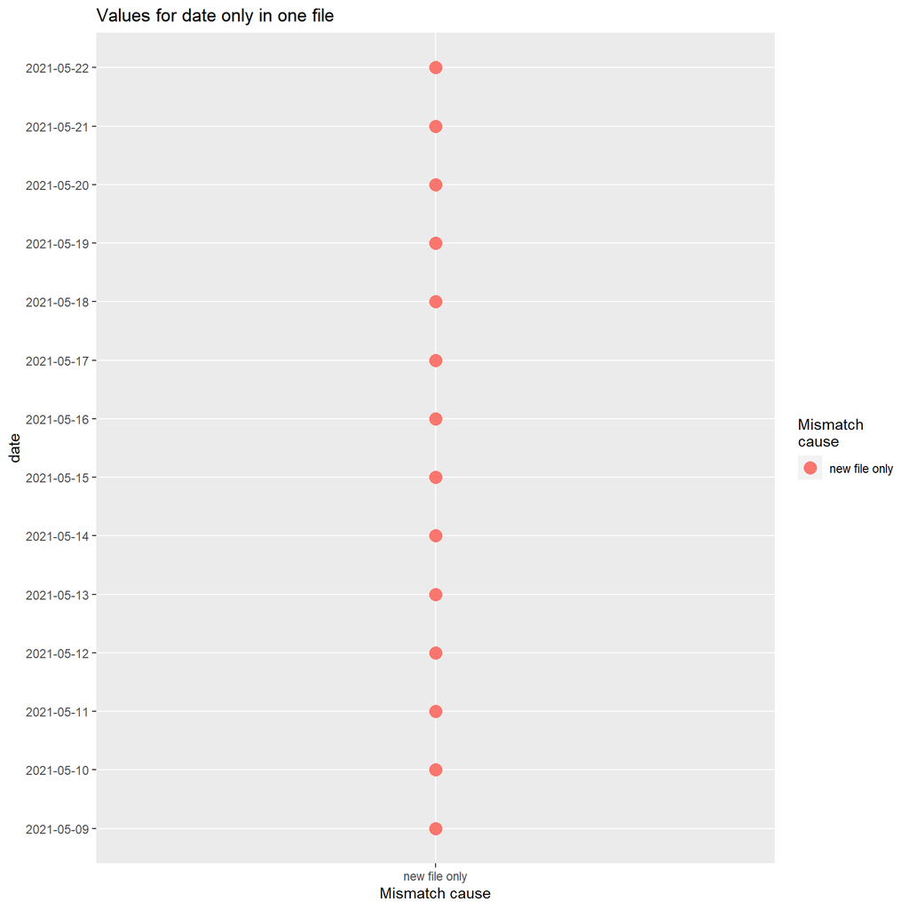

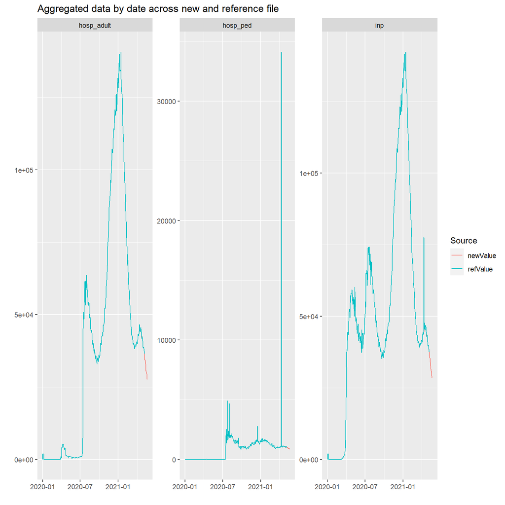

```
##
##
## ***Differences of at least 5 and at least 5%
##
## 3 records
## Detailed output available in log: ./RInputFiles/Coronavirus/Coronavirus_CDC_Daily_210528.log
```

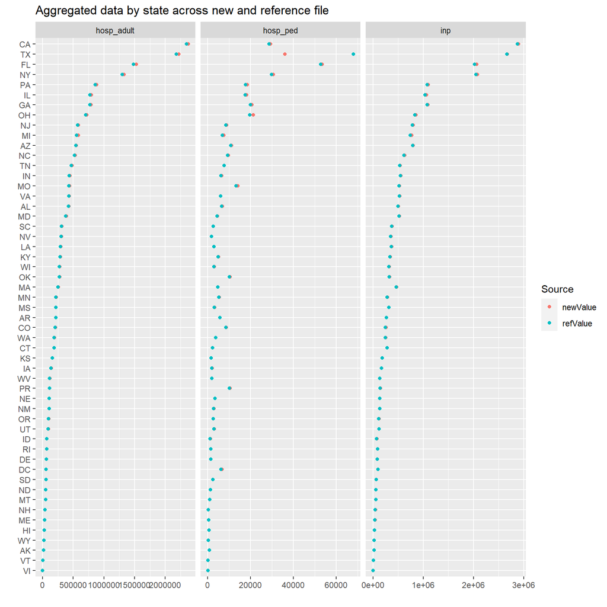

```
##
##
## ***Differences of at least 0 and at least 0.1%
##
## 49 records
## Detailed output available in log: ./RInputFiles/Coronavirus/Coronavirus_CDC_Daily_210528.log
##
##
## Column sums before and after applying filtering rules:
## # A tibble: 3 x 6
##   isType tot_cases tot_deaths new_cases   new_deaths         n
##   <chr>      <dbl>      <dbl>     <dbl>        <dbl>     <dbl>
## 1 before   5.99e+9    1.24e+8   3.29e+7 577667       28969
## 2 after    5.96e+9    1.23e+8   3.28e+7 575010       25041
## 3 pctchg   4.37e-3    3.82e-3   4.55e-3      0.00460     0.136
##
##
## Column sums before and after applying filtering rules:
## # A tibble: 3 x 5
##   isType     inp hosp_adult    hosp_ped          n
##   <chr>    <dbl>      <dbl>       <dbl>      <dbl>
## 1 before 2.61e+7    2.03e+7 415621      23972
## 2 after  2.60e+7    2.02e+7 405188      23109
## 3 pctchg 5.67e-3    5.73e-3      0.0251     0.0360
```

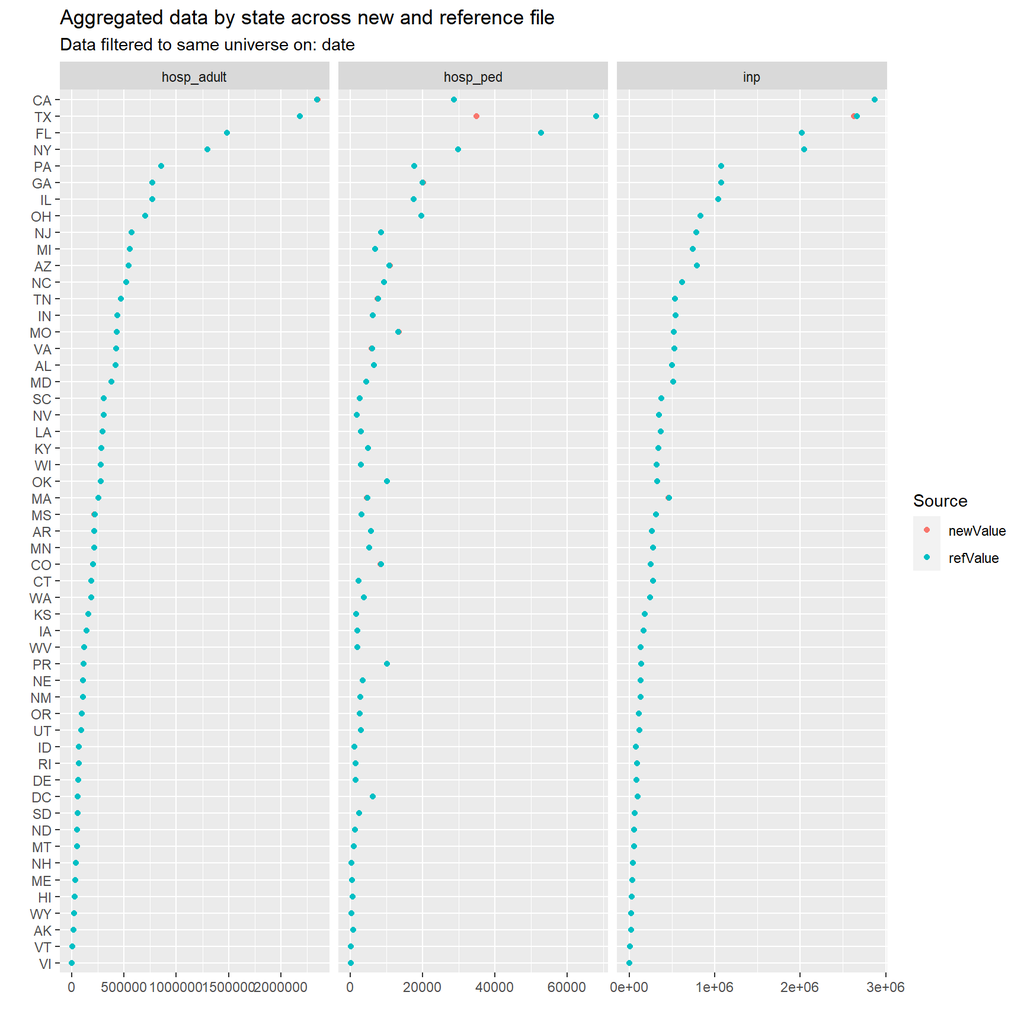

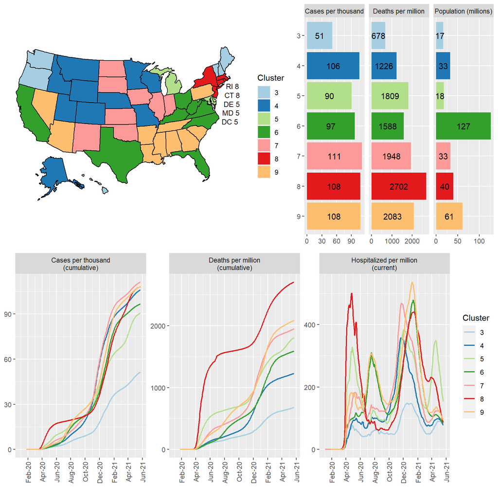

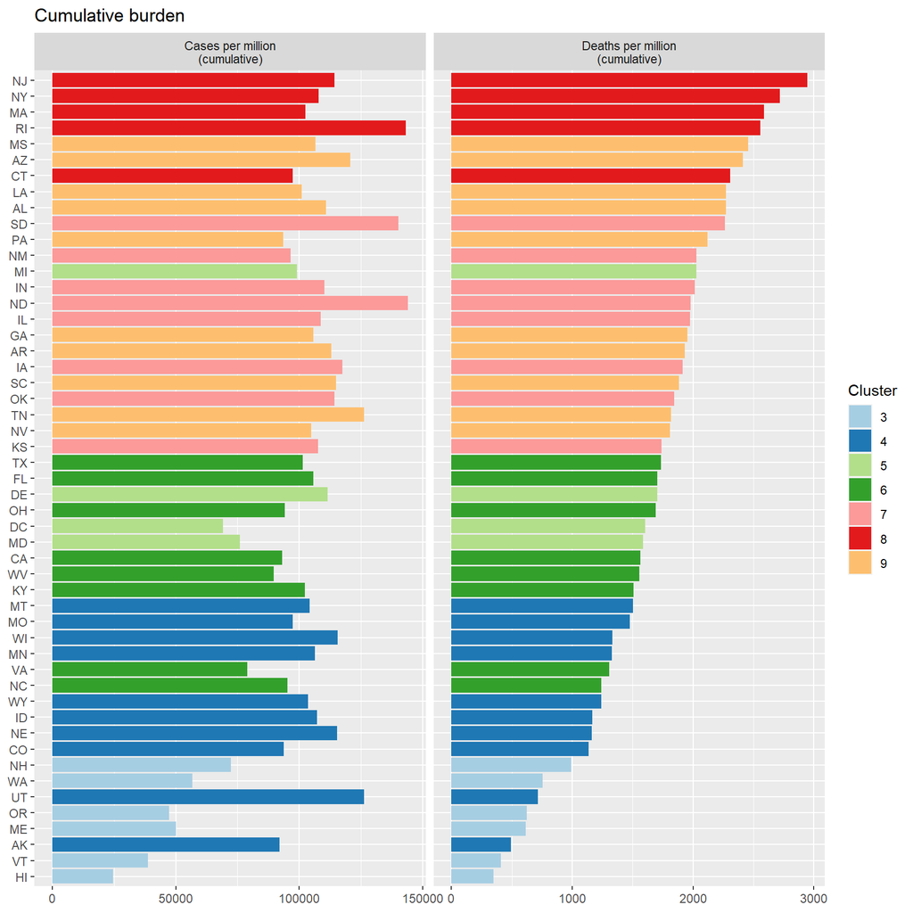

[2 more figures not shown]

```r
readList <- list("cdcDaily"="./RInputFiles/Coronavirus/CDC_dc_downloaded_210528.csv",
                 "cdcHosp"="./RInputFiles/Coronavirus/CDC_h_downloaded_210528.csv"
                 )
compareList <- list("cdcDaily"=readFromRDS("cdc_daily_test_v3")$dfRaw$cdcDaily,
                    "cdcHosp"=readFromRDS("cdc_daily_test_v3")$dfRaw$cdcHosp
                    )

cdc_daily_210528 <- readRunCDCDaily(thruLabel="May 28, 2021",
                                    downloadTo=lapply(readList, FUN=function(x) if(file.exists(x)) NA else x),
                                    readFrom=readList,
                                    compareFile=compareList,
                                    writeLog="./RInputFiles/Coronavirus/Coronavirus_CDC_Daily_210528.log",
                                    useClusters=readFromRDS("cdc_daily_test_v2")$useClusters,
                                    skipAssessmentPlots=FALSE,
                                    brewPalette="Paired"
                                    )
```

```r
saveToRDS(cdc_daily_210528, ovrWrite=FALSE, ovrWriteError=FALSE)
```

The process appears to work as intended. Next steps are to update the county-level data process, making use of some of the functions available for CDC data processing.